# dplyr：数据集操作

邱飞

万里学院

## 筛选

- 要把握市场的总体特征的话，我们需要市场的全部数据。
- 但是，操作最终都是落实到具体的个股上。
- 所以，我们最终需要筛选出感兴趣的个股。

## 获得上市公司名称数据

- 本课程用到的数据集中的上市公司代码和名称列表存在再这里
- https://raw.githubusercontent.com/qiufei/stockcode/master/stockcode.csv

```r
library(readr)

code_name = read_csv("https://raw.githubusercontent.com/qiufei/stockcode/master/stockcode.csv",
            col_names = TRUE)
```

## 查看数据集的结构

- head函数得到数据集的前6行记录
- 可以看到股票的名称存储在stockname列

```r
name_head = head(code_name)
library(knitr)
kable(name_head)
```

| stockname | sename | stockcode |
| --- | --- | --- |
| 平安银行 | SZ000001 | 000001.SZ |
| 万 科Ａ | SZ000002 | 000002.SZ |
| 国农科技 | SZ000004 | 000004.SZ |
| 世纪星源 | SZ000005 | 000005.SZ |
| 深振业Ａ | SZ000006 | 000006.SZ |
| 零七股份 | SZ000007 | 000007.SZ |

## 分组计算：获得每只股票的每天的日收益率

- 我们的数据集stock中有1500多只股票，要一个个计算的话太麻烦。
- 所以我们要用到dplyr宏包来进行分组计算。

## 原始的stock只是一个数据集

```r
str(stock)
```

```
## 'data.frame':    1016475 obs. of  7 variables:
##  $ code  : Factor w/ 1547 levels "SHA600000","SHA600004",..: 1 1 1 1 1 1 1 1 1 1 ...
##  $ date  : Date, format: "2017-01-18" "2017-01-17" ...
##  $ open  : num  16.4 16.5 16.2 16.1 16.2 ...
##  $ high  : num  16.6 16.5 16.6 16.3 16.2 ...
##  $ low   : num  16.4 16.4 16.1 16.1 16.1 ...
##  $ close : num  16.5 16.4 16.6 16.3 16.1 ...
##  $ volume: num  11478663 12555292 53304724 19034143 8296150 ...
```

## 利用group_by函数对stock进行分组

- 按照股票代码code来分组

```r
library(dplyr)
stock_grouped = group_by(stock,code)
str(stock_grouped)
```

[output not shown]

[output cut: 64 more lines]

[output not shown]

## 对数据按照时间升序排列

- 收益率计算是用今天的收盘价除以昨天的收盘价再减去1

> return = close/lag(close) - 1
- 收益率的计算公式要求时间从早到晚排列。

```r
stock_sort = arrange(stock_grouped,date)
```

## 对每只股票计算每天的收益率

```r
stock_return = transmute(stock_sort,
                         date = date,
                         return = close/lag(close) -1)
```

## 下面进入筛选环节

- 我们对股市最感兴趣的数据集是收益率
- 现在这个数据已经被我们计算得到，后面我们的分析以这个数据集为计算
- 将这个数据集重命名为return，会面的分析以return为基础，而不再是以stock为基础。

## 收益率数据集

```r
return = na.omit(stock_return) # 清除没有收益率的第一期的NA值
save(return,file = "return.rda") # 将收益率数据集到当前路径下
head(return)
```

```
## Source: local data frame [6 x 3]
## Groups: code [6]
##
##        code       date       return
##      <fctr>     <date>        <dbl>
## 1 SHA601111 2012-11-27 -0.012987013
## 2 SHE002002 2012-11-27 -0.015286624
## 3 SHE002004 2012-11-27 -0.009365994
## 4 SHE002005 2012-11-27  0.019642857
## 5 SHE002007 2012-11-27 -0.006054960
## 6 SHE002008 2012-11-27 -0.021505376
```

## 为什么要用去除空值的na.omit函数

```r
head(stock_return)
```

```
## Source: local data frame [6 x 3]
## Groups: code [6]
##
##        code       date return
##      <fctr>     <date>  <dbl>
## 1 SHA601111 2012-11-26     NA
## 2 SHE002002 2012-11-26     NA
## 3 SHE002004 2012-11-26     NA
## 4 SHE002005 2012-11-26     NA
## 5 SHE002007 2012-11-26     NA
## 6 SHE002008 2012-11-26     NA
```

## 筛选：选出上证和深证指数的收益率

- 在我们的数据集中，上证指数的代码是`SHA000001`,深证指数的代码是`SHE399001`。

```r
hushen_1 = filter(return,code == "SHA000001" | code == "SHE399001")
```

## 画出沪深两市历史收益率的折线图

我也觉得数据看起来很枯燥，所以我们来画个图。

```r
library(ggplot2)
hushen_plot1 = ggplot(hushen_1,
                      aes(x = date, y = return,color = code))+
                      geom_line()
```

## show plot1

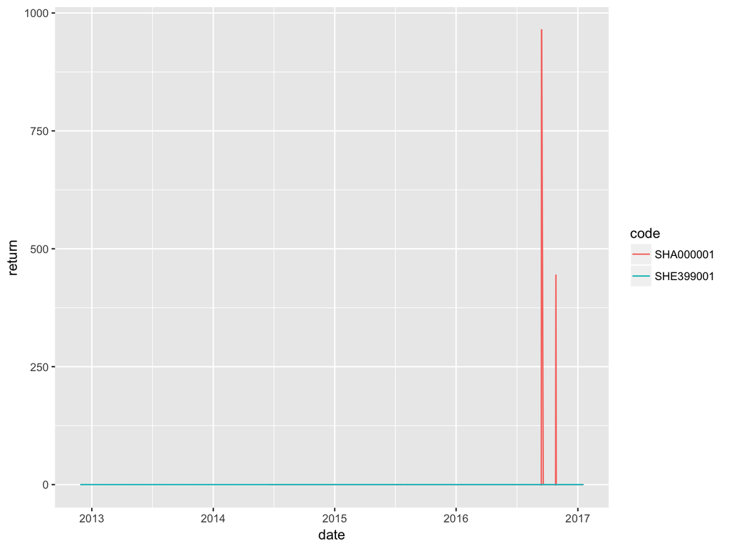

## 找出上证收益率最大值的记录所在行

```r
hushen_1[hushen_1$return == max(hushen_1$return),]
```

```
## Source: local data frame [1 x 3]
## Groups: code [1]
##
##        code       date   return
##      <fctr>     <date>    <dbl>
## 1 SHA000001 2016-09-14 964.5466
```

## 找出异常值前后的股指原始数据

```r
max_error1 = filter(stock_sort,
                    code == "SHA000001",
                    date == "2016-09-13")
max_error1
```

```
## Source: local data frame [1 x 7]
## Groups: code [1]
##
##        code       date  open  high   low close   volume
##      <fctr>     <date> <dbl> <dbl> <dbl> <dbl>    <dbl>
## 1 SHA000001 2016-09-13  3.09  3.11  3.07  3.11 12286226
```

```r
return_right1 = filter(return,
                       !(code == "SHA000001" & date == "2016-09-13"))

return_right2 = filter(return_right1,
                       !(code == "SHA000001" & date == "2016-09-14"))
```

## 以新的收益率数据集画图

```r
hushen_2 = filter(return_right2,
                 code == "SHA000001" | code == "SHE399001")
hushen_plot2 = ggplot(hushen_2,
              aes(x = date, y = return,color = code))+
              geom_line()
```

## show plot2

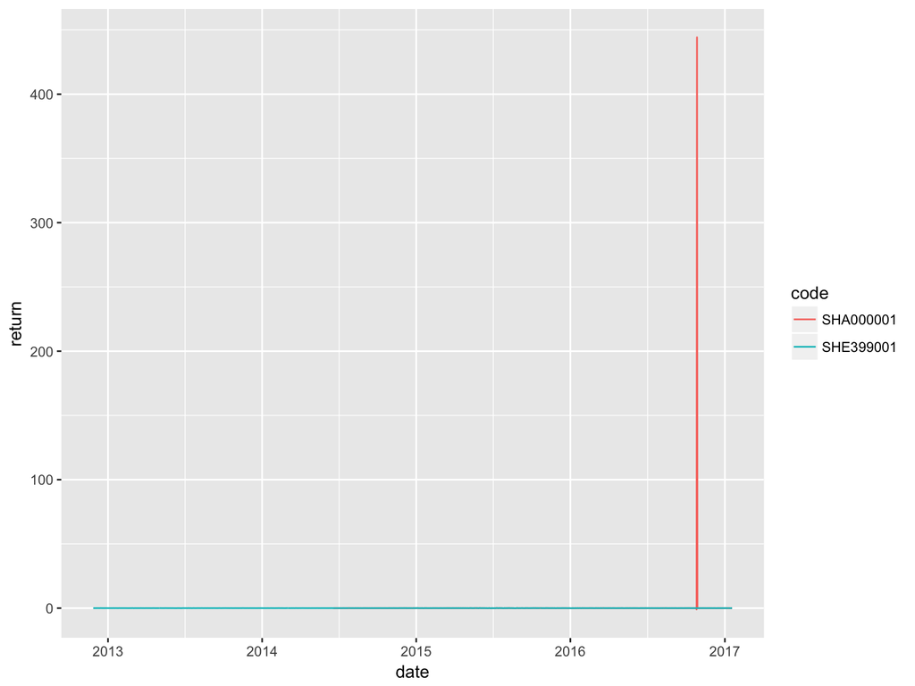

## 从图形上看，还有一个异常值，再找出这个异常值

- 重复上面的代码，所以直接写了。

```r
max_error2 = hushen_2[hushen_2$return == max(hushen_2$return),]

max_error2
```

```
## Source: local data frame [1 x 3]
## Groups: code [1]
##
##        code       date   return
##      <fctr>     <date>    <dbl>
## 1 SHA000001 2016-10-27 444.2575
```

```r
return_right3 = filter(return_right2,
                       !(code == "SHA000001" & date == "2016-10-27"))

return_right4 = filter(return_right3,
                       !(code == "SHA000001" & date == "2016-10-28"))
```

## 再次画图，发现有异常的最小值

```r
hushen_3 = filter(return_right4,
                 code == "SHA000001" | code == "SHE399001")
hushen_plot3 = ggplot(hushen_3,
                aes(x = date, y = return,color = code))+
                geom_line()
```

## show plot3

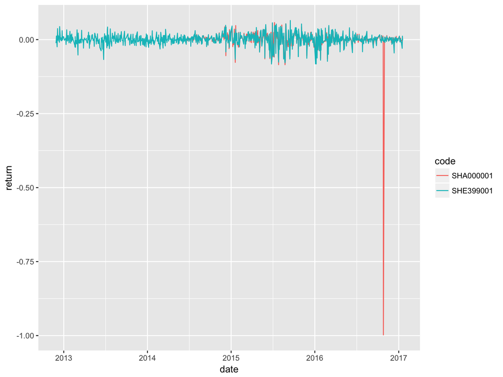

## 再来一次去除最小异常址的过程

```r
min_error = hushen_3[hushen_3$return == min(hushen_3$return),]

min_error
```

```
## Source: local data frame [1 x 3]
## Groups: code [1]
##
##        code       date     return
##      <fctr>     <date>      <dbl>
## 1 SHA000001 2016-10-26 -0.9977682
```

```r
return_right5 = filter(return_right4,
                       !(code == "SHA000001" & date == "2016-10-26"))
```

## 沪深收益率最终画图

```r
hushen_4 = filter(return_right5,
                 code == "SHA000001" | code == "SHE399001")

hushen_plot_final = ggplot(hushen_4,
                           aes(x = date, y = return,color = code))+
                    geom_line()
```

## show final picture

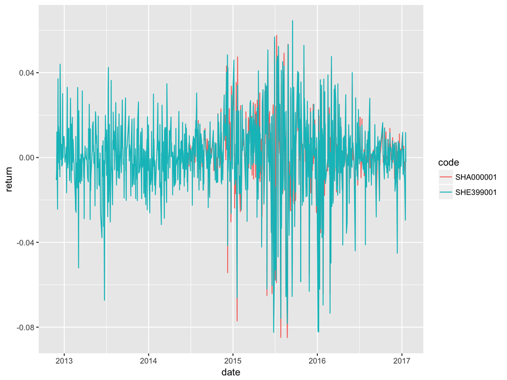

## 关于沪深两市收益率的一个结论

从图中我们可以看到，绿色的线（深证收益率）几乎盖住了红色的线（上证指数），这说明：

- 在一般情况下，深证指数的波动较大
- 但是在特殊时期，上证的波动比深证大